# Bergen Machine Learning Meetup

## Getting imagenet predictions

The setup of the imagenet model is now complete, so all we have to do is grab a batch of images and call *predict()* on them.

```python
batch_size = 4
```

Keras provides functionality to create batches of data from directories containing images; all we have to do is to define the size to resize the images to, what type of labels to create, whether to randomly shuffle the images, and how many images to include in each batch. We use this little wrapper to define some helpful defaults appropriate for imagenet data:

```python
def get_batches(dirname, gen=image.ImageDataGenerator(), shuffle=True,
                batch_size=batch_size, class_mode='categorical'):
    return gen.flow_from_directory(str(path/dirname), target_size=(224,224),
                class_mode=class_mode, shuffle=shuffle, batch_size=batch_size)
```

From here we can use exactly the same steps as before to look at predictions from the model.

```
Found 20000 images belonging to 2 classes.
Found 5000 images belonging to 2 classes.
```

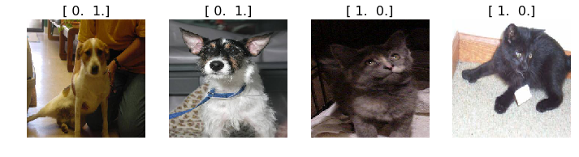

```python
batches = get_batches('train', batch_size=batch_size)
val_batches = get_batches('valid', batch_size=batch_size)
imgs,labels = next(batches)

# This shows the 'ground truth'
plots(imgs, titles=labels)
```

The VGG model returns 1,000 probabilities for each image, representing the probability that the model assigns to each possible imagenet category for each image. By finding the index with the largest probability (with *np.argmax()*) we can find the predicted label.

```python
def pred_batch(imgs):
    preds = model.predict(imgs)
    idxs = np.argmax(preds, axis=1)

    print('Shape: {}'.format(preds.shape))
    print('First 5 classes: {}'.format(classes[:5]))
    print('First 5 probabilities: {}\n'.format(preds[0, :5]))
    print('Predictions prob/class: ')

    for i in range(len(idxs)):
        idx = idxs[i]
        print ('  {:.4f}/{}'.format(preds[i, idx], classes[idx]))
```

```python
pred_batch(imgs)
```

```
Shape: (4, 1000)
First 5 classes: ['tench', 'goldfish', 'great_white_shark', 'tiger_shark', 'hammerhead']
First 5 probabilities: [  1.9574e-04   3.8791e-04   1.9536e-04   4.2055e-05   4.1180e-04]

Predictions prob/class:
  0.2186/carousel
  0.2906/miniature_schnauzer
  0.4407/keeshond
  0.4058/schipperke
```

### Loading/saving images

Loading and resizing the images every time we want to use them isn't necessary - instead we should save the processed arrays. By far the fastest way to save and load numpy arrays is using bcolz. This also compresses the arrays, so we save disk space. Here are the functions we'll use to save and load using bcolz.

```python
import bcolz
def save_array(fname, arr): c=bcolz.carray(arr, rootdir=fname, mode='w'); c.flush()
def load_array(fname): return bcolz.open(fname)[:]
```

```python
from utils import get_data
val_data = get_data(str(path/'valid'))
trn_data = get_data(str(path/'train'))
```

```
Found 5000 images belonging to 2 classes.
Found 20000 images belonging to 2 classes.
```

```python
trn_data.shape
```

```
(20000, 3, 224, 224)
```

```python
model_path = str(path / 'models')
print(model_path)
```

[output not shown]

```python
if not os.path.exists(model_path): os.mkdir(model_path)
```

```python
save_array(model_path + 'train_data.bc', trn_data)
save_array(model_path + 'valid_data.bc', val_data)
```

### finetuning

We start by removing the last layer, and telling Keras that we want to fix the weights in all the other layers (since we aren't looking to learn new parameters for those other layers).

```python
??vgg.finetune
model.pop()
for layer in model.layers: layer.trainable=False
model.add(Dense(2, activation='softmax'))
```

```python
# compile it
from keras.optimizers import Adam
opt = Adam(lr=0.1)
model.compile(optimizer=opt,
                loss='categorical_crossentropy', metrics=['accuracy'])
```

```python
#convenience function
def fit_model(model, batches, val_batches, nb_epoch=1):
    model.fit_generator(batches, samples_per_epoch=batches.N, nb_epoch=nb_epoch,
                        validation_data=val_batches, nb_val_samples=val_batches.N)

#train the last layer of the model
fit_model(model, batches, val_batches, nb_epoch=2)
```

[output not shown]